# Teste de Hipóteses

Joysce Lopes

2022-11-20

# 1 Exercicio 1.1 - Teste T emparelhado

Queremos saber se as médias dos índices de placas bacterianas são iguais antes e após a escovação, considerando o uso de uma escova convencional. Para isso, vamos aplicar um teste t emparelhado para duas amostras, pois as amostras são dependentes. O teste t emparelhado neste caso, é o ideal pois as observações foram colhidas aos pares, sob condições homogêneas (observações de antes e depois são do mesmo indivíduo), embora essas condições possam mudar de um par para o outro (cada par de observações pertence a um indíviduo). Primeiramente, vamos fazer a leitura dos dados obtidos:

Consideramos as seguintes suposições:  
1. Seja $(X_{11},X_{12});...;(X_{n1},X_{n2})$ um conjunto de n observações emparelhadas;  
2. $\mu_1$ e $\sigma_1$ a média e o desvio padrão dos índices antes da escovação, respectivamente;  
3. $\mu_2$ e $\sigma_2$ a média e o desvio padrão dos índices após a escovação, respectivamente;  
4. As diferenças entre os pares de observações são denotadas por: $D_i=X_{i1}-X_{i2}$, i= 1,2…n;  
5. $\mu_d$ e $\sigma_d$ a média e o desvio padrão da diferença dos índices antes e depois da escovação, respectivamente;  
6. As diferenças $D_i$ são consideradas normalmente distribuídas com média $\mu_d = E(D_i) = E(X_{i1}-X_{i2}) = \mu_1-\mu_2$  
7. $\sigma_d$ é desconhecido, porém pode ser estimado por $S_d^{2} = \frac{1}{n-1}\Sigma(D_i-\bar{D})²$, em que $\bar{D}=\frac{1}{n}\Sigma D_i$;  
8. Podemos aplicar um teste t como no caso de uma amostra para testar as hipóteses:  
$H_0: \mu_d = \Delta_0$ | $H_0: \mu_d = \Delta_0$ | $H_0: \mu_d = \Delta_0$  
$H_1: \mu_d \neq \Delta_0$ | $H_1: \mu_d > \Delta_0$ | $H_1: \mu_d < \Delta_0$  
9. Sob $H_0$, a estatística de teste será: $T = \frac{\bar{D}-\Delta_0}{S_d/\sqrt{n}}\sim t_{n-1}$

Neste caso, iremos aplicar um teste unilateral superior:  
$H_0: \mu_d = \Delta_0$  
$H_1: \mu_d > \Delta_0$  
Onde $\Delta_0 = 0$.

## 1.1 Método tradicional

A região de não rejeição: $RA = {x \in R: x \le t_{\alpha,n-1}}$  
E a região de rejeição: $RR = {x \in R: x > t_{\alpha,n-1}}$  
Onde, $\alpha$ = 0.05, n = 26 e $t_{\alpha,n-1}$ é o que chamamos de valor crítico. Logo, temos que o valor crítico é:

```
## valor critico =  1.71
```

Assim, podemos ilustrar graficamente as regiões de rejeição da hipótese nula:

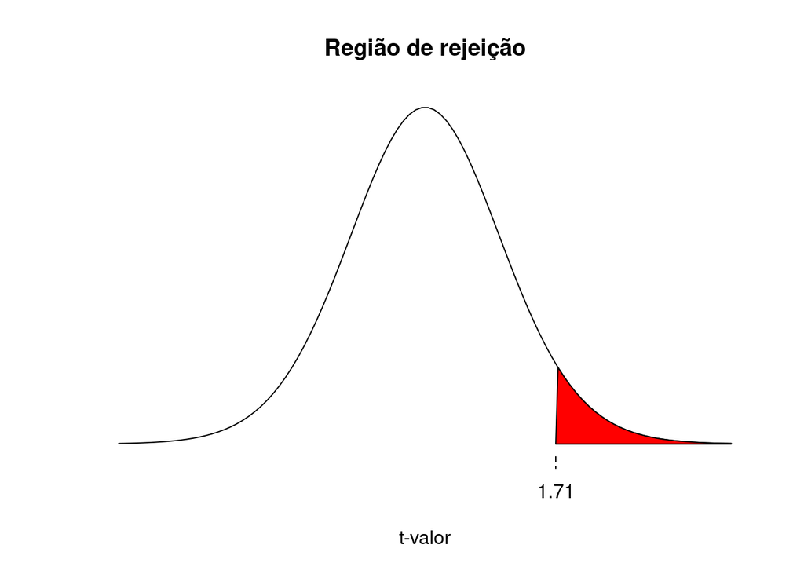

Vamos calcular o valor da estatística de teste:

```
## Estatística de teste = 7.812733
```

Logo, percebemos que o valor da estatística de teste é maior que o valor crítico, portanto esta está na região de rejeição. E por fim, concluímos que, a nível de 95% de confiança, há evidências que nos levam a rejeitar a hipótese nula, sendo assim, as médias dos índices de antes e depois da escovação, não são iguais.

## 1.2 Método Intervalos de confiança

Vamos calcular o intervalo de confiança:

```
## (IC,95%) = 0.8796361 Inf
```

```
##
## Média das diferenças = 1.125769
```

Como percebemos, há uma chance de 95% da média das diferenças estar entre o IC encontrado. Como o IC não inclui o valor zero, rejeitamos a hipótese nula, com 95% de confiança.

## 1.3 Método P-valor

```
## P-valor = 1.804436e-08
```

Como P-valor << $\alpha$, rejeitamos a hipótese nula, à um nível de 5% de significância.

## 1.4 Boxplots

Além disso, como $H_1$ é a hipótese não rejeitada, $\mu_d>0 = \mu_1-\mu_2>0 = \mu_1>\mu_2$, podemos concluir que os dados evidenciam que o uso da escova convencional fez com que os índices de placas bacterianas diminuíssem, em média.  
Os boxplots abaixo, podem nos ajudar a visualizar o resultado obtido.

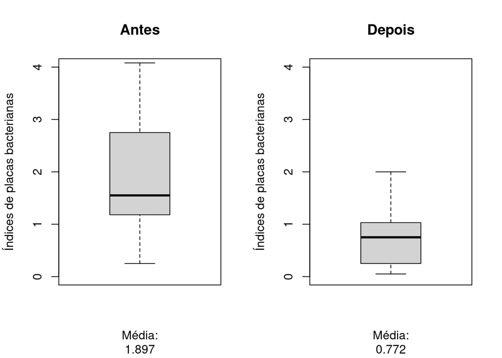

# 2 Exercício 1.2 - Teste T emparelhado

Neste caso, iremos comparar o desempenho de duas escovas diferentes (Convencional e Hugges) sendo que estas foram aplicadas na mesma amostra.  
Aqui, vamos optar em aplicar o teste bilateral, a fim de demostrar outras possíveis formas de analisar e interpretar os valores obtidos no teste.

Neste caso, temos um teste bilateral com as seguintes hipóteses:  
$H_0: \mu_d = \Delta_0$  
$H_1: \mu_d \neq \Delta_0$  
Onde $\Delta_0 = 0$ e $\mu_d = \mu_c-\mu_h$

## 2.1 Método tradicional

A região de não rejeição: $RA = {x \in R: |x| \le t_{\alpha/2,n-1}}$  
E a região de rejeição: $RR = {x \in R: |x| > t_{\alpha/2,n-1}}$  
Onde, $\alpha$ = 0.05, n = 26 e $t_{\alpha/2,n-1}$ é o que chamamos de valor crítico. Logo, temos que o valor crítico é:

```
## valor critico =  2.06
```

Assim, podemos ilustrar graficamente as regiões de rejeição da hipótese nula:

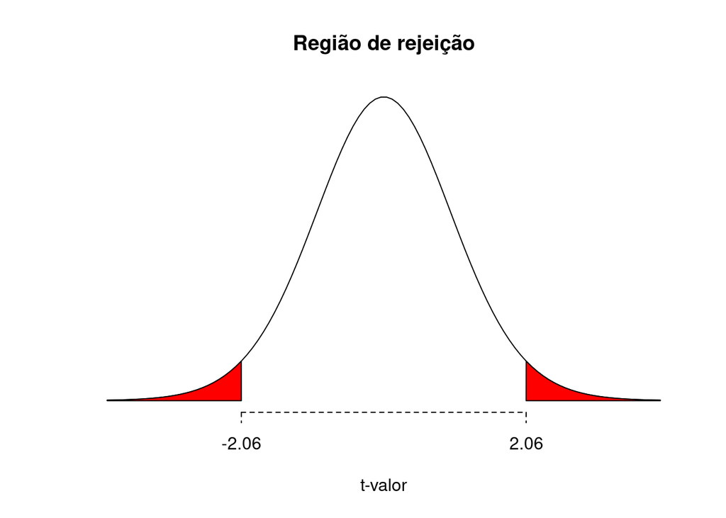

Encontrando a estatística de teste:

```
## Estatística de teste = 4.257878
```

Como o valor da estatística de teste está na área de rejeição, rejeitamos a hipótese nula, à nível de 5% de significância.

## 2.2 Método Intervalo de confiança

```
## (IC,95%) = 0.2559653 0.7355731
```

```
## Média das diferenças = 0.4957692
```

Como percebemos, há uma chance de 95% da média das diferenças estar entre o IC encontrado. Como o IC não inclui o valor zero, rejeitamos a hipótese nula, com 95% de confiança.

## 2.3 Método P-valor

```
## P-valor = 0.0002548988
```

Como P-valor << $\alpha$, rejeitamos a hipótese nula, à um nível de significância de 5%. Logo, as médias dos índices de placas bacterianas após a escovação com uma escova convencional e uma escova hugger, não são iguais.

## 2.4 Boxplots

Se observamos a diferença entre as médias das duas escovas, temos que:

```
## Média das diferenças =  0.4957692
```

Logo, $\mu_c-\mu_h>0 => \mu_c>\mu_h$. Ou seja, os índices de placas bacterianas após a escovação usando uma escova hugger, em média, são menores quando comparados à escova convencional.

Os boxplots abaixo podem ilustrar o resultado obtido:

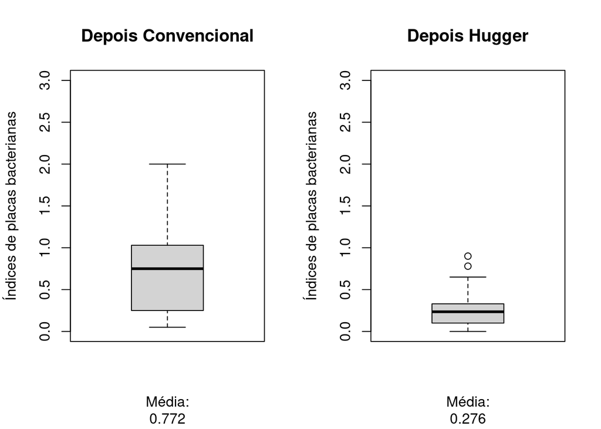

# 3 Exercício 2.1

Neste exercício, queremos saber se as médias das turmas F e G ($\mu_f$ e $\mu_g$) são iguais ou não. Ou seja, faremos o teste para duas amostras independentes.

Temos um teste bilateral:  
$H_0: \mu_f=\mu_g = \mu_f-\mu_g =0$  
$H_1: \mu_f \neq \mu_g = \mu_f-\mu_g\neq0$

### 3.0.1 Teste das variâncias

Mas antes, como as variâncias populacionais são desconhecidas, devemos testá-las a fim de decidir qual teste t iremos aplicar

```
##
##  F test to compare two variances
##
## data:  Dados$Probabilidade...Turma.F and Dados$Probabilidade...Turma.G
## F = 1.3143, num df = 41, denom df = 49, p-value = 0.358
## alternative hypothesis: true ratio of variances is not equal to 1
## 95 percent confidence interval:
##  0.731240 2.400144
## sample estimates:
## ratio of variances
##           1.314338
```

## 3.1 Método tradicional

A região de não rejeição: $RA = {x \in R: |x| \le t_{\alpha/2,v}}$  
E a região de rejeição: $RR = {x \in R: |x| > t_{\alpha/2,v}}$  
Onde, $\alpha$ = 0.05, v = 90 e $t_{\alpha/2,v}$ é o que chamamos de valor crítico. Logo, temos que o valor crítico é:

```
## valor critico =  1.99
```

Assim, podemos ilustrar graficamente as regiões de rejeição da hipótese nula:

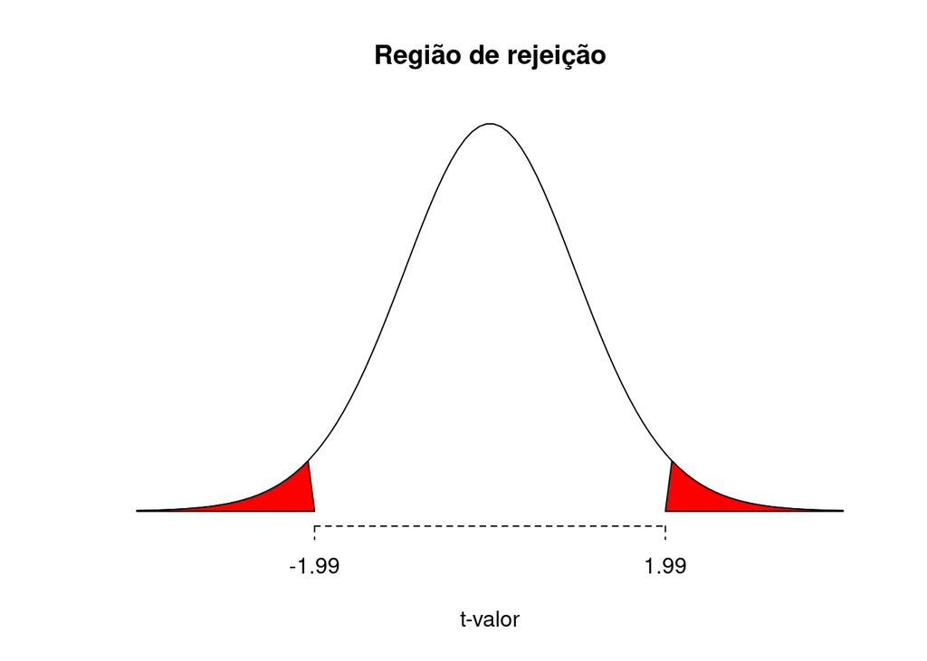

Encontrando a estatística de teste:

```
## Estatística de teste = -1.201391
```

Como o valor da estatística de teste não está na área de rejeição, não rejeitamos a hipótese nula, à nível de 5% de significância.

## 3.2 Método do Intervalos de confiança

```
## (IC,95%) = -10.87114 2.684476
```

```
## Diferença das médias = -4.093333
```

Como percebemos, há uma chance de 95% da diferença das médias estar entre o IC encontrado. Como o IC inclui o valor zero, não rejeitamos a hipótese nula, com 95% de confiança.

## 3.3 Método P-valor

```
## P-valor = 0.2330539
```

## 3.4 Boxplots

Podemos notar a semelhança das notas das turmas:

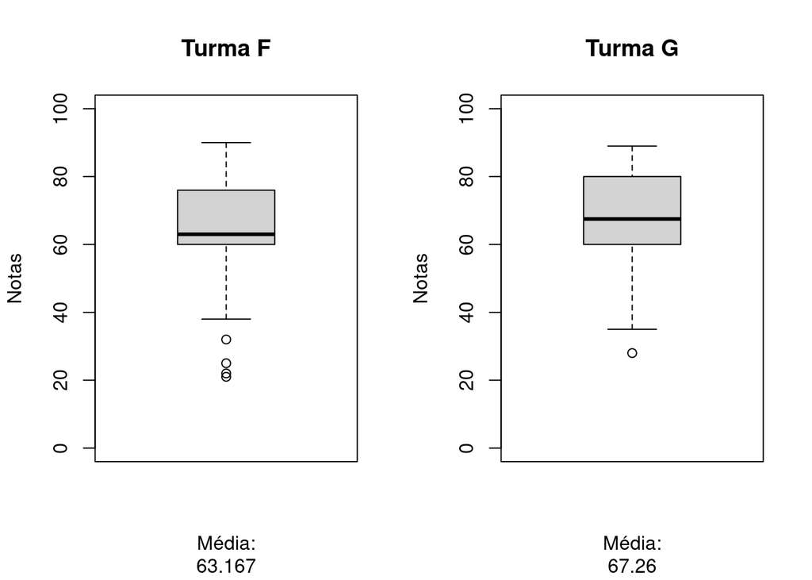

# 4 Exercício 2.2

Neste exercício gostaríamos de saber se na turma G, as médias das notas de homens e mulheres são iguais ou se a média das notas das mullheres é maior que a média dos homens.

Temos um teste unilateral superior:  
$H_0: \mu_f-\mu_m = 0$  
$H_1: \mu_f-\mu_m >0$

### 4.0.1 Teste das variâncias

Mas antes, como as variâncias populacionais são desconhecidas, devemos testá-las a fim de decidir qual teste t iremos aplicar

```
##
##  F test to compare two variances
##
## data:  Dados$Probabilidade...Turma.G[Dados$Gênero...Turma..G == "F"] and Dados$Probabilidade...Turma.G[Dados$Gênero...Turma..G == "M"]
## F = 1.2936, num df = 16, denom df = 32, p-value = 0.5195
## alternative hypothesis: true ratio of variances is not equal to 1
## 95 percent confidence interval:
##  0.5754297 3.3027284
## sample estimates:
## ratio of variances
##           1.293574
```

## 4.1 Método tradicional

A região de não rejeição: $RA = {x \in R: x \le t_{\alpha,v}}$  
E a região de rejeição: $RR = {x \in R: x > t_{\alpha,v}}$  
Onde, $\alpha$ = 0.05, v = 48 e $t_{\alpha,v}$ é o que chamamos de valor crítico.

Logo, temos que o valor crítico é:

```
## valor critico =  1.68
```

Assim, podemos ilustrar graficamente as regiões de rejeição da hipótese nula:

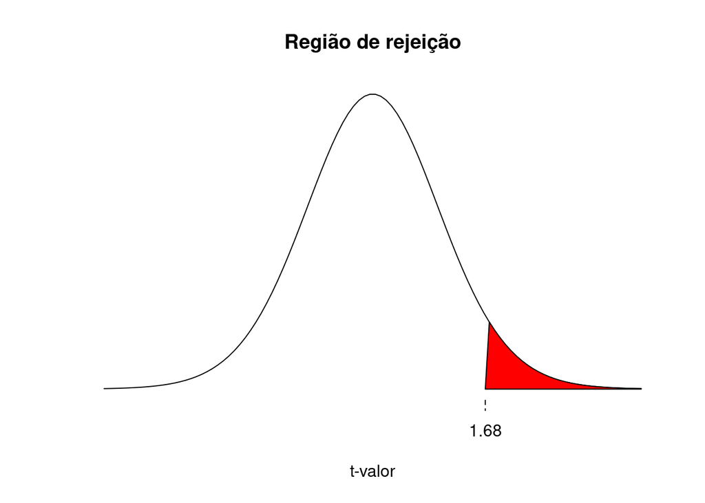

Encontrando a estatística de teste:

```
## Estatística de teste = -0.8241113
```

Logo, a estatística de teste não está na área de rejeição. Então, não rejeitamos a hipótese nula à um nível de 5% de significância, não havendo evidências que comprovem a nota superior das mulheres em relação aos homens da turma G.

## 4.2 Método do Intervalos de confiança

```
## (IC,95%) = -11.84882 Inf
```

```
## Diferença das médias =  -3.869875
```

Como percebemos, há uma chance de 95% da diferença das médias estar entre o IC encontrado. Como o IC inclui o valor zero, não rejeitamos a hipótese nula, com 95% de confiança.

## 4.3 Método P-valor

```
## P-valor = 0.7916965
```

O P-valor > $\alpha$, então não rejitamos a hipótese nula. Sendo assim, não há evidências, com nível de 5% de significância, que a média das notas das mulheres seja maior que a média das notas dos homens da turma G.

## 4.4 Boxplots

Podemos notar a semelhança das notas das mulheres e homens da turma G:

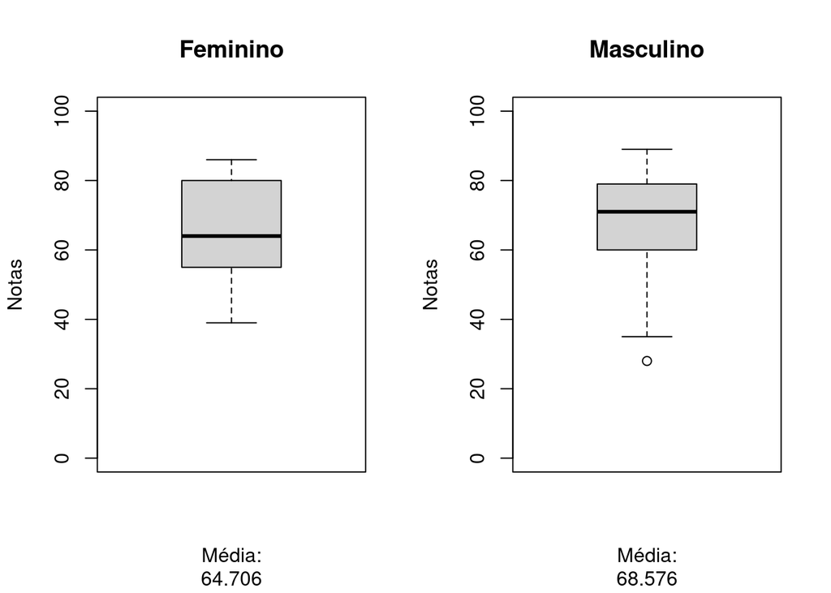